# Bootcamp_6_4_Extension_Task

**Part A: Produce the Insight**

1. Prepare the data
2. Make one justified cleaning decision
3. Ask an analytical question
4. Analyse before you plot
5. Choose the visual deliberately
6. Challenge the visual
7. Communicate the result

```python
from google.colab import files
csv = files.upload()
```

Upload widget is only available when the cell has been executed in the current browser session. Please rerun this cell to enable.

```
Saving Happiness.csv to Happiness (2).csv
```

**1. Load the dataset into Pandas and preview**

```python
import pandas as pd
bs = pd.read_csv('Happiness.csv')
bs
```

|  | Country | Region | Happiness Rank | Happiness Score | Lower Confidence Interval | Upper Confidence Interval | Economy (GDP per Capita) | Family | Health (Life Expectancy) | Freedom | Trust (Government Corruption) | Generosity | Dystopia Residual |
| --- | --- | --- | --- | --- | --- | --- | --- | --- | --- | --- | --- | --- | --- |
| 0 | Denmark | Western Europe | 1 | 7.526 | 7.460 | 7.592 | 1.44178 | 1.16374 | 0.79504 | 0.57941 | 0.44453 | 0.36171 | 2.73939 |
| 1 | Switzerland | Western Europe | 2 | 7.509 | 7.428 | 7.590 | 1.52733 | 1.14524 | 0.86303 | 0.58557 | 0.41203 | 0.28083 | 2.69463 |
| 2 | Iceland | Western Europe | 3 | 7.501 | 7.333 | 7.669 | 1.42666 | 1.18326 | 0.86733 | 0.56624 | 0.14975 | 0.47678 | 2.83137 |
| 3 | Norway | Western Europe | 4 | 7.498 | 7.421 | 7.575 | 1.57744 | 1.12690 | 0.79579 | 0.59609 | 0.35776 | 0.37895 | 2.66465 |
| 4 | Finland | Western Europe | 5 | 7.413 | 7.351 | 7.475 | 1.40598 | 1.13464 | 0.81091 | 0.57104 | 0.41004 | 0.25492 | 2.82596 |
| ... | ... | ... | ... | ... | ... | ... | ... | ... | ... | ... | ... | ... | ... |
| 152 | Benin | Sub-Saharan Africa | 153 | 3.484 | 3.404 | 3.564 | 0.39499 | 0.10419 | 0.21028 | 0.39747 | 0.06681 | 0.20180 | 2.10812 |
| 153 | Afghanistan | Southern Asia | 154 | 3.360 | 3.288 | 3.432 | 0.38227 | 0.11037 | 0.17344 | 0.16430 | 0.07112 | 0.31268 | 2.14558 |
| 154 | Togo | Sub-Saharan Africa | 155 | 3.303 | 3.192 | 3.414 | 0.28123 | 0.00000 | 0.24811 | 0.34678 | 0.11587 | 0.17517 | 2.13540 |
| 155 | Syria | Middle East and Northern Africa | 156 | 3.069 | 2.936 | 3.202 | 0.74719 | 0.14866 | 0.62994 | 0.06912 | 0.17233 | 0.48397 | 0.81789 |
| 156 | Burundi | Sub-Saharan Africa | 157 | 2.905 | 2.732 | 3.078 | 0.06831 | 0.23442 | 0.15747 | 0.04320 | 0.09419 | 0.20290 | 2.10404 |

157 rows × 13 columns

**1. Check its shape, column names, data types and missing values.**

- bs.null().sum() - Used to check if the dataset has any null values
- bs.dtypes - Used to check the datatype of each column

```python
print(bs.shape, bs.columns, bs.dtypes, bs.isnull().sum(), sep='\n\n')
```

```
(157, 13)

Index(['Country', 'Region', 'Happiness Rank', 'Happiness Score',
       'Lower Confidence Interval', 'Upper Confidence Interval',
       'Economy (GDP per Capita)', 'Family', 'Health (Life Expectancy)',
       'Freedom', 'Trust (Government Corruption)', 'Generosity',
       'Dystopia Residual'],
      dtype='object')

Country                           object
Region                            object
Happiness Rank                     int64
Happiness Score                  float64
Lower Confidence Interval        float64
Upper Confidence Interval        float64
Economy (GDP per Capita)         float64
Family                           float64
Health (Life Expectancy)         float64
Freedom                          float64
Trust (Government Corruption)    float64
Generosity                       float64
Dystopia Residual                float64
dtype: object

Country                          0
Region                           0
Happiness Rank                   0
Happiness Score                  0
Lower Confidence Interval        0
Upper Confidence Interval        0
Economy (GDP per Capita)         0
Family                           0
Health (Life Expectancy)         0
Freedom                          0
Trust (Government Corruption)    0
Generosity                       0
Dystopia Residual                0
dtype: int64
```

**2. Identify one potential data-quality issue or consistency check. Apply an appropriate cleaning step only if one is needed. Use a comment to explain why you made the change. If no change is needed, explain how you established that.**

After checking for duplicates there were a couple of columns that had a small amount of duplicate values, most of which could be ignored as there it is completely possible for multiple countires to have the same values in each category.

However, I thought it would be best to check the three duplicates that appear in the Happiness Rank column to confirm if these duplicates are mistakes or becuase they share the same rank due to the score being the same. The answer is the latter. This is also re-confirmed as there is no rank 35, 58, or 146.

As there are no duplicate errors, NaN values, incorrect datatypes, i have come to the conslusion the dataset is clean and there is no need for any cleaning steps to take.

```python
bs.apply(pd.Series.duplicated).sum()
```

|  | 0 |
| --- | --- |
| Country | 0 |
| Region | 147 |
| Happiness Rank | 3 |
| Happiness Score | 3 |
| Lower Confidence Interval | 3 |
| Upper Confidence Interval | 3 |
| Economy (GDP per Capita) | 0 |
| Family | 0 |
| Health (Life Expectancy) | 1 |
| Freedom | 0 |
| Trust (Government Corruption) | 1 |
| Generosity | 0 |
| Dystopia Residual | 0 |

**dtype:** int64

```python
bs[bs["Happiness Rank"].duplicated(keep=False)]
```

|  | Country | Region | Happiness Rank | Happiness Score | Lower Confidence Interval | Upper Confidence Interval | Economy (GDP per Capita) | Family | Health (Life Expectancy) | Freedom | Trust (Government Corruption) | Generosity | Dystopia Residual |
| --- | --- | --- | --- | --- | --- | --- | --- | --- | --- | --- | --- | --- | --- |
| 33 | Saudi Arabia | Middle East and Northern Africa | 34 | 6.379 | 6.287 | 6.471 | 1.48953 | 0.84829 | 0.59267 | 0.37904 | 0.30008 | 0.15457 | 2.61482 |
| 34 | Taiwan | Eastern Asia | 34 | 6.379 | 6.305 | 6.453 | 1.39729 | 0.92624 | 0.79565 | 0.32377 | 0.06630 | 0.25495 | 2.61523 |
| 56 | Poland | Central and Eastern Europe | 57 | 5.835 | 5.749 | 5.921 | 1.24585 | 1.04685 | 0.69058 | 0.45190 | 0.05500 | 0.14443 | 2.20035 |
| 57 | South Korea | Eastern Asia | 57 | 5.835 | 5.747 | 5.923 | 1.35948 | 0.72194 | 0.88645 | 0.25168 | 0.07716 | 0.18824 | 2.35015 |
| 144 | Burkina Faso | Sub-Saharan Africa | 145 | 3.739 | 3.647 | 3.831 | 0.31995 | 0.63054 | 0.21297 | 0.33370 | 0.12533 | 0.24353 | 1.87319 |
| 145 | Uganda | Sub-Saharan Africa | 145 | 3.739 | 3.629 | 3.849 | 0.34719 | 0.90981 | 0.19625 | 0.43653 | 0.06442 | 0.27102 | 1.51416 |

```python
print(bs['Happiness Rank'].iloc[33:36], bs['Happiness Rank'].iloc[56:59], bs['Happiness Rank'].iloc[144:147], sep='\n\n')
```

```
33    34
34    34
35    36
Name: Happiness Rank, dtype: int64

56    57
57    57
58    59
Name: Happiness Rank, dtype: int64

144    145
145    145
146    147
Name: Happiness Rank, dtype: int64
```

**3. Ask an analytical question**

Write one question that the dataset can answer. Examples include: How are marks distributed? Which region has the most records? How do average values compare between categories? Your question should determine the analysis and chart you choose.

Question: Which region has the highest average Happiness Score?

**4. Analyse before you plot**

Use Pandas to calculate the information needed to answer your question. This might involve filtering, value_counts(), groupby(), mean(), median(), min(), max(), describe() or another method covered in the workshop.

```python
avg_hs = bs.groupby(['Region'])['Happiness Score'].mean().round(2).sort_values(ascending=False).reset_index()
avg_hs
```

|  | Region | Happiness Score |
| --- | --- | --- |
| 0 | Australia and New Zealand | 7.32 |
| 1 | North America | 7.25 |
| 2 | Western Europe | 6.69 |
| 3 | Latin America and Caribbean | 6.10 |
| 4 | Eastern Asia | 5.62 |
| 5 | Middle East and Northern Africa | 5.39 |
| 6 | Central and Eastern Europe | 5.37 |
| 7 | Southeastern Asia | 5.34 |
| 8 | Southern Asia | 4.56 |
| 9 | Sub-Saharan Africa | 4.14 |

**5. Choose the visual deliberately**

Create an appropriate chart using Matplotlib, Seaborn or Pandas plotting. Give it a useful title and label the axes where appropriate. Under the chart, write 2–3 sentences explaining why the chart suits your question and what it shows.

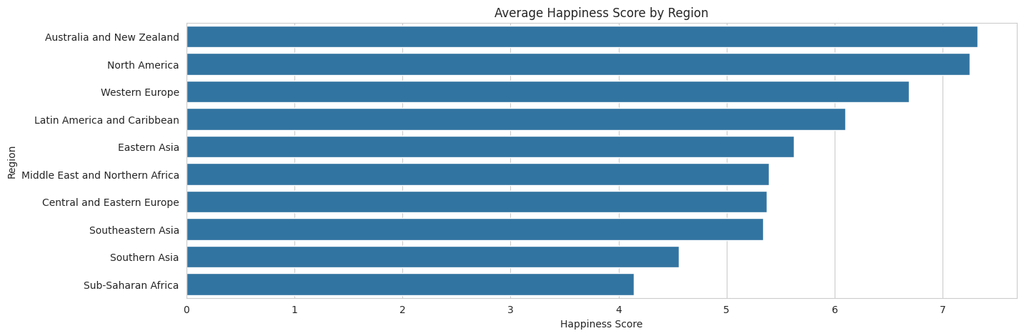

```python
import matplotlib.pyplot as plt
import seaborn as sns

plt.figure(figsize=(15, 5))
sns.barplot(y='Region', x='Happiness Score', data = avg_hs)
plt.title('Average Happiness Score by Region')
plt.show()
```

**6. Challenge the visual**

Create a second, different chart from the same dataset. Decide whether the second chart communicates the information better or worse than the first and explain why. The aim is to practise judgement, not simply make more charts.

Although you could reach the same conclusion using the line chart below, it presents the information in a less clear and potentially more confusing way. At a quick glance, the connected line may suggest that the chart is showing how happiness scores change over time, rather than comparing the average happiness score across different regions.

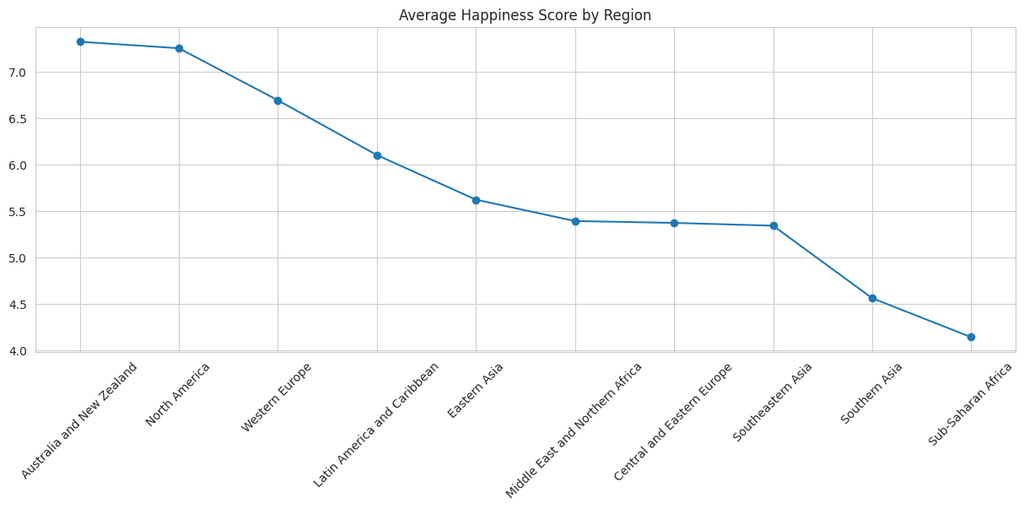

```python
plt.figure(figsize=(15, 5))
plt.plot(avg_hs['Region'], avg_hs['Happiness Score'], marker='o')
plt.title('Average Happiness Score by Region')
plt.xticks(rotation=45)
plt.show()
```

**7. Communicate the result**

Write a short three-point update to your manager: What did you investigate? What did you find? What would you recommend checking or analysing next?

**Initial Investigation**

> After reviewing the available data, I wanted to investigate the happiness score across each region to identify which regions were the happiest and which had the lowest levels of happiness.

**Results**

> After filtering the data and grouping it by region, the results showed that Australia & New Zealand had the highest average happiness score at 7.32, while Sub-Saharan Africa had the lowest at 4.14.

**Further Analysis**

> We can dive deeper into the data by using the happiness score as a reference point to investigate whether any of the other statistics are contributing to the differences in happiness between regions. For example, we could investigate whether there is a correlation between happiness and the average GDP per region, or between happiness and average trust in government.